# ESM 206 Lab 5

rubyhg

10/28/2019

# New markdown

## Objectives:

- Getting counts for different groups
- Use {lubridate} to parse dates
- Find confidence intervals & do t-tests with t.test()
- Heatmap with geom_tile()

# first thing is to attach packages at the top of the new markdown

```r
# Import lobster data!

lobster_abundance <- read_csv(here::here("data", "lobster_abundance.csv"), na = "-99999") %>%
  clean_names()
```

Use the tidyr::uncount() function to expand a frequency variable

```r
lobster_tidy <- lobster_abundance %>%
  tidyr::uncount(lobster_count)
```

Yay! Now each lobster has its own row. This is a tidy format.

Let’s look at this a bunch of ways:

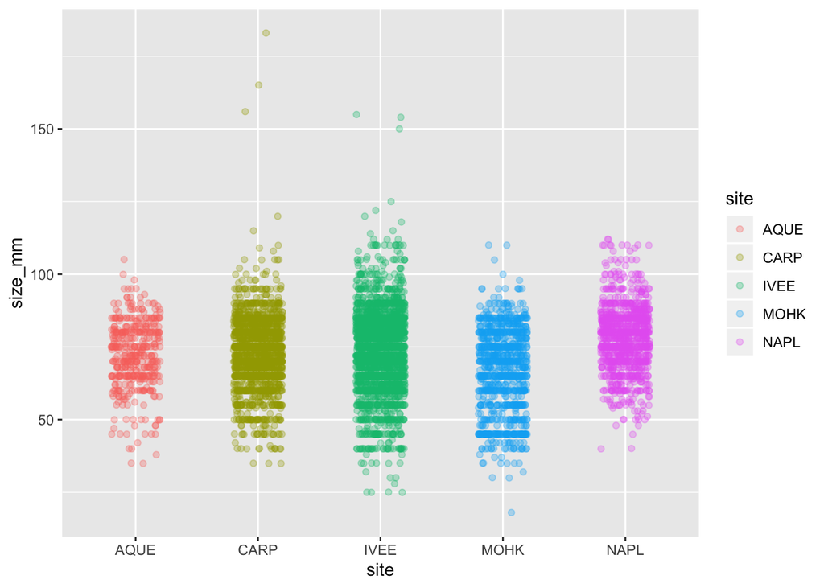

```r
ggplot(data = lobster_tidy, aes(x = site, y = size_mm)) +
  geom_jitter(aes(color = site),
              width = 0.2,
              alpha = 0.3)
```

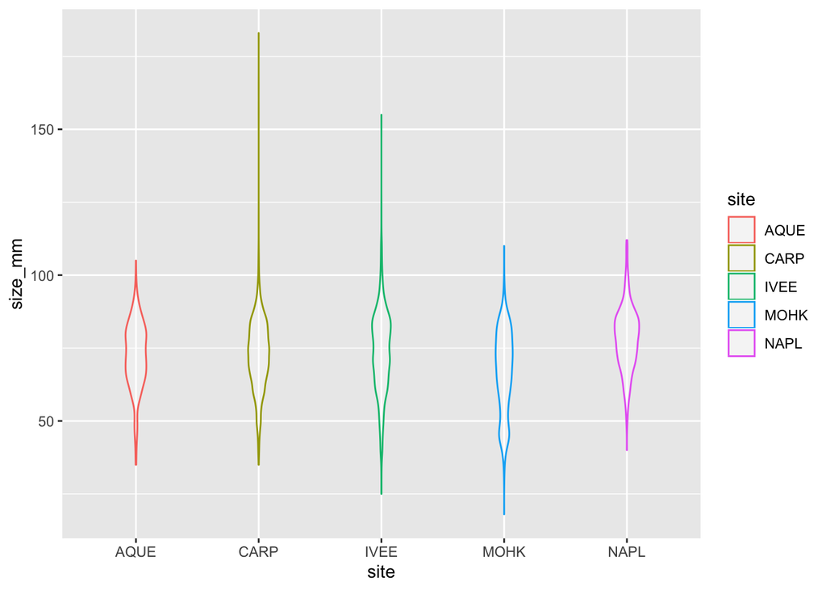

```r
ggplot(data = lobster_tidy, aes(x = site, y = size_mm)) +
  geom_violin(aes(color = site),
              width = 0.2,
              alpha = 0.3)
```

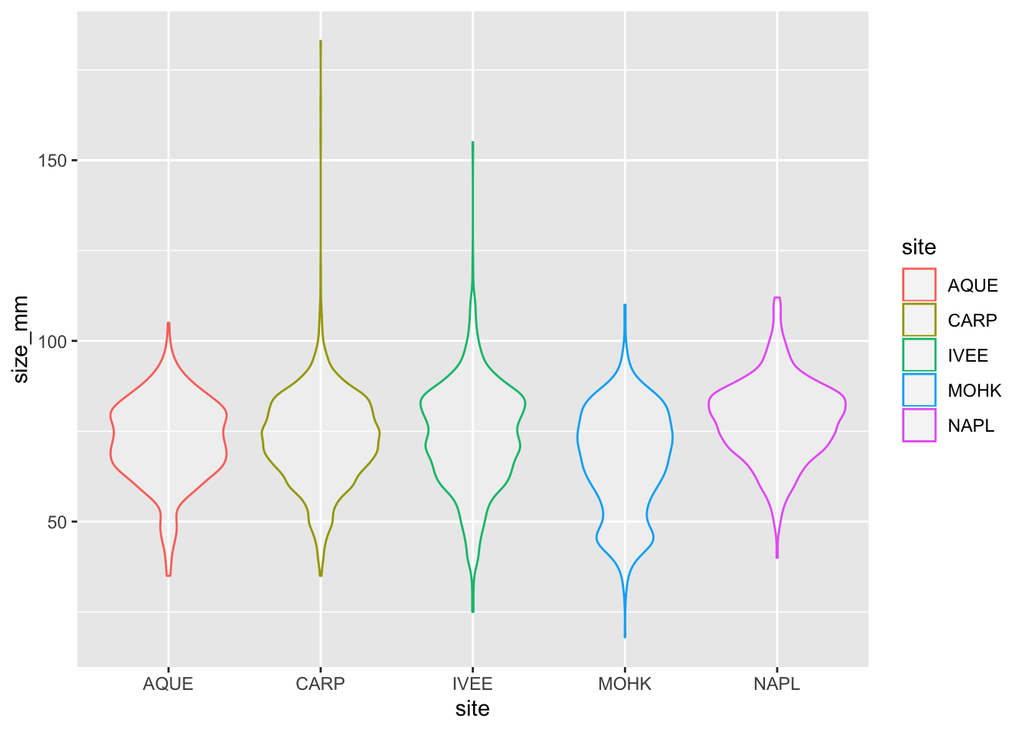

```r
ggplot(data = lobster_tidy, aes(x = site, y = size_mm)) +
  geom_violin(aes(color = site),
              alpha = 0.3)
```

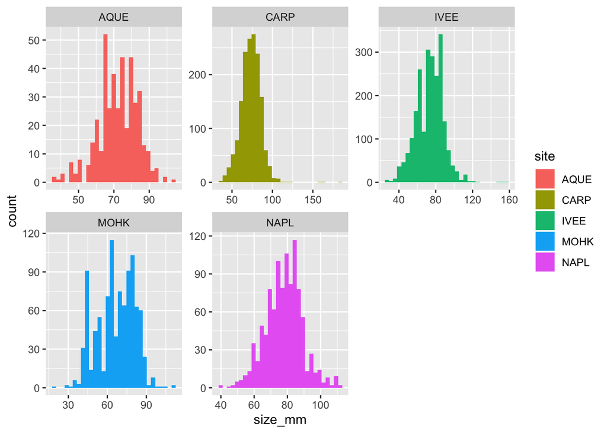

```r
ggplot(data = lobster_tidy, aes(x = size_mm)) +
  geom_histogram(aes(fill = site)) +
  facet_wrap(~site, scales = "free")
```

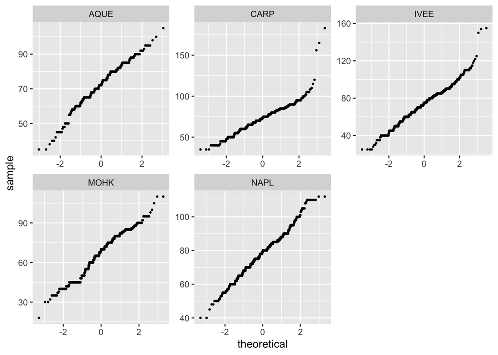

```r
ggplot(data = lobster_tidy, aes(sample = size_mm)) +
  geom_qq(size = 0.5) +
  facet_wrap(~site, scales = "free")
```

Use “lubridate” to parse dates and times:

First, need to make “date” a variable not a character > class(lobster_tidy$date) [1] “character” > lobster_date <- lobster_tidy %>% + mutate{ I’m going to add a new column with ‘mutate()’, that contains my date as an actual date

```r
lobster_date <- lobster_tidy %>%
  mutate(
    date_new = lubridate::mdy(date)
  )
```

> View(lobster_date) class(lobster_date$date_new) [1] “Date”

Parse “date” column to get the differenct pieces (month, year) separated

```r
lobster_parse_date <- lobster_date %>%
  mutate(
    obs_month = lubridate::month(date_new, label = TRUE),
    obs_year = lubridate::year(date_new)
  )
```

label = TRUE to see month name (below shows that months are in order, this is how you view that) > class(lobster_parse_date$obs_month) [1] "ordered" "factor" > levels(lobster_parse_date$obs_month) [1] “Jan” “Feb” “Mar” “Apr” “May” “Jun” “Jul” “Aug” “Sep” “Oct” “Nov” “Dec”

obs_year = lubridate::year(date_new) creates a new column for year

Count lobsters by different groupings… count function is great for categorical data if you want to get total numbers

?count (this format gives you a description of the term)

Let’s say I want to count the number of lobsters by year and month

```r
lobster_ym <- lobster_parse_date %>%
  count(obs_year, obs_month)

lobster_ym
```

```
## # A tibble: 8 x 3
##   obs_year obs_month     n
##      <dbl> <ord>     <int>
## 1     2012 Aug         231
## 2     2013 Aug         243
## 3     2014 Aug         404
## 4     2014 Sep         106
## 5     2015 Aug        1100
## 6     2016 Aug         809
## 7     2017 Aug        1668
## 8     2018 Aug        1805
```

What about for each year and site?

```r
lobster_ym <- lobster_parse_date %>%
  count(obs_year, obs_month)

lobster_ysite <- lobster_parse_date %>%
  count(obs_year, site)

lobster_ysite
```

```
## # A tibble: 35 x 3
##    obs_year site      n
##       <dbl> <chr> <int>
##  1     2012 AQUE     38
##  2     2012 CARP     78
##  3     2012 IVEE     26
##  4     2012 MOHK     83
##  5     2012 NAPL      6
##  6     2013 AQUE     32
##  7     2013 CARP     93
##  8     2013 IVEE     40
##  9     2013 MOHK     15
## 10     2013 NAPL     63
## # … with 25 more rows
```

```r
lobster_ym <- lobster_parse_date %>%
  count(obs_year, obs_month)

lobster_ysite <- lobster_parse_date %>%
  count(obs_year, site)

lobster_ysite
```

```
## # A tibble: 35 x 3
##    obs_year site      n
##       <dbl> <chr> <int>
##  1     2012 AQUE     38
##  2     2012 CARP     78
##  3     2012 IVEE     26
##  4     2012 MOHK     83
##  5     2012 NAPL      6
##  6     2013 AQUE     32
##  7     2013 CARP     93
##  8     2013 IVEE     40
##  9     2013 MOHK     15
## 10     2013 NAPL     63
## # … with 25 more rows
```

```r
lobster_site <- lobster_parse_date %>%
  count(site)

lobster_site
```

```
## # A tibble: 5 x 2
##   site      n
##   <chr> <int>
## 1 AQUE    422
## 2 CARP   1619
## 3 IVEE   2304
## 4 MOHK    982
## 5 NAPL   1039
```

Count is only so good, what if you want summaries and means and observations? Use group_by

```r
lobster_ym <- lobster_parse_date %>%
  count(obs_year, obs_month)

lobster_ysite <- lobster_parse_date %>%
  count(obs_year, site)

lobster_ysite
```

```
## # A tibble: 35 x 3
##    obs_year site      n
##       <dbl> <chr> <int>
##  1     2012 AQUE     38
##  2     2012 CARP     78
##  3     2012 IVEE     26
##  4     2012 MOHK     83
##  5     2012 NAPL      6
##  6     2013 AQUE     32
##  7     2013 CARP     93
##  8     2013 IVEE     40
##  9     2013 MOHK     15
## 10     2013 NAPL     63
## # … with 25 more rows
```

```r
lobster_site <- lobster_parse_date %>%
  count(site)

lobster_site
```

```
## # A tibble: 5 x 2
##   site      n
##   <chr> <int>
## 1 AQUE    422
## 2 CARP   1619
## 3 IVEE   2304
## 4 MOHK    982
## 5 NAPL   1039
```

```r
# group_by + summarize + n() (this makes a new chart!)
lobster_summary <- lobster_parse_date %>%
  group_by(site) %>%
  summarize(
    mean_size = mean(size_mm, na.rm = TRUE),
    sd_size = sd(size_mm, na.rm = TRUE),
    sample_n = n()
  )
```

Confidence intervals and t-tests

Use the “t-test()” function to find confidence intervals and perform t-tests

We want to find the confidence interval for lobster sizes at Isla Vista beach

```r
ivee_lobster <- lobster_tidy %>%
  filter(site == "IVEE") %>%
  pull(size_mm)

# pull() shows specific values (just a list)

t.test(ivee_lobster)
```

```
##
##  One Sample t-test
##
## data:  ivee_lobster
## t = 245.23, df = 2302, p-value < 2.2e-16
## alternative hypothesis: true mean is not equal to 0
## 95 percent confidence interval:
##  72.99130 74.16806
## sample estimates:
## mean of x
##  73.57968
```

```r
#t.test() is a one sample t-test
# confidence int tells us something about the sampling distribution - where would we expect to samples to fall 95% of the time?
# sample mean (even if you took a ton more samples), we expect the sample to fall within the confidence interval 95% of the time
# not the probability that the true population will exist in this range, but that I would expect any sample I take to fall within this interval 95% of the time
```

Two-sample t-test: Is there a significant difference in mean lobster lengths between Naples Reef and Mohawk Reef?

```r
napl_sample <- lobster_tidy %>%
  filter(site == "NAPL") %>%
  pull(size_mm)


mohk_sample <- lobster_tidy %>%
  filter(site == "MOHK") %>%
  pull(size_mm)

# to use a two-way t-test, include both variables in t.test()
mohk_napl_ttest <- t.test(napl_sample, mohk_sample)
mohk_napl_ttest
```

```
##
##  Welch Two Sample t-test
##
## data:  napl_sample and mohk_sample
## t = 19.849, df = 1850.8, p-value < 2.2e-16
## alternative hypothesis: true difference in means is not equal to 0
## 95 percent confidence interval:
##  10.19806 12.43436
## sample estimates:
## mean of x mean of y
##  78.18454  66.86833
```

```r
# p-value = almost at zero. there is only a x probability that I could have taken two samples from pops with the same mean, and found by random chance with means of that difference...?
```

Mean lobster size differed significantly between Mohawk and Naples reefs (t(1850.7720862) = 19.849)